# Rigde-Lasso as to changing penalty values

WooramSeong

04-16-2021

# 1 준비작업

## 1.1 필요 라이브러리

```r
library(tidymodels)
library(tidyverse)
library(magrittr)
library(skimr)
library(knitr)
library(naniar)
library(car)
library(glmnet)
library(doParallel)
theme_set(theme_bw())
```

## 1.2 파일경로 라이브러리

```r
file_path <-  "/cloud/project/input"
files <- list.files(file_path)
files
```

```
## [1] "test.csv"  "train.csv"
```

```r
train <- read_csv(file.path(file_path, "train.csv"))
test <- read_csv(file.path(file_path, "test.csv"))
```

# 2 Data overview (데이터 기본정보)

## 2.1 기본 정보

Train - 총 1460개의 행, 81개의 열로 이루어져있고,  
Test - 목표 변수인 SalePrice를 제외한 80개의 열로 이루어져있다. 행은 1459개이다.

Train의 정보를 통해 회귀분석을 실행하고, 해당 회귀분석 식이 Test의 정보에 얼마나 잘 들어맞는지 예측해보자.

## 2.2 Recipe Code

```r
all_data <- bind_rows(train, test) %>%
  janitor::clean_names()
names(all_data)[1:81]
```

```
##  [1] "id"              "ms_sub_class"    "ms_zoning"       "lot_frontage"
##  [5] "lot_area"        "street"          "alley"           "lot_shape"
##  [9] "land_contour"    "utilities"       "lot_config"      "land_slope"
## [13] "neighborhood"    "condition1"      "condition2"      "bldg_type"
## [17] "house_style"     "overall_qual"    "overall_cond"    "year_built"
## [21] "year_remod_add"  "roof_style"      "roof_matl"       "exterior1st"
## [25] "exterior2nd"     "mas_vnr_type"    "mas_vnr_area"    "exter_qual"
## [29] "exter_cond"      "foundation"      "bsmt_qual"       "bsmt_cond"
## [33] "bsmt_exposure"   "bsmt_fin_type1"  "bsmt_fin_sf1"    "bsmt_fin_type2"
## [37] "bsmt_fin_sf2"    "bsmt_unf_sf"     "total_bsmt_sf"   "heating"
## [41] "heating_qc"      "central_air"     "electrical"      "x1st_flr_sf"
## [45] "x2nd_flr_sf"     "low_qual_fin_sf" "gr_liv_area"     "bsmt_full_bath"
## [49] "bsmt_half_bath"  "full_bath"       "half_bath"       "bedroom_abv_gr"
## [53] "kitchen_abv_gr"  "kitchen_qual"    "tot_rms_abv_grd" "functional"
## [57] "fireplaces"      "fireplace_qu"    "garage_type"     "garage_yr_blt"
## [61] "garage_finish"   "garage_cars"     "garage_area"     "garage_qual"
## [65] "garage_cond"     "paved_drive"     "wood_deck_sf"    "open_porch_sf"
## [69] "enclosed_porch"  "x3ssn_porch"     "screen_porch"    "pool_area"
## [73] "pool_qc"         "fence"           "misc_feature"    "misc_val"
## [77] "mo_sold"         "yr_sold"         "sale_type"       "sale_condition"
## [81] "sale_price"
```

```r
housing_recipe <- all_data %>%
  recipe(sale_price ~ .) %>%
  step_rm(id) %>%
  step_log(sale_price) %>%
  step_modeimpute(all_nominal()) %>%
  step_dummy(all_nominal()) %>%
  step_meanimpute(all_predictors()) %>%
  step_normalize(all_predictors()) %>%
  ##step_nzv(all_predictors()) %>%
  prep(training = all_data)

print(housing_recipe)
```

```
## Data Recipe
##
## Inputs:
##
##       role #variables
##    outcome          1
##  predictor         80
##
## Training data contained 2919 data points and 2919 incomplete rows.
##
## Operations:
##
## Variables removed id [trained]
## Log transformation on sale_price [trained]
## Mode Imputation for ms_zoning, street, alley, ... [trained]
## Dummy variables from ms_zoning, street, alley, lot_shape, ... [trained]
## Mean Imputation for ms_sub_class, lot_frontage, ... [trained]
## Centering and scaling for ms_sub_class, lot_frontage, ... [trained]
```

```r
all_data2 <- juice(housing_recipe)
train_index <- seq_len(nrow(train))

train2 <- all_data2[train_index,]
test2 <- all_data2[-train_index,]
train2 %>%
  head() %>%
  kable()
```

| ms_sub_class | lot_frontage | lot_area | overall_qual | overall_cond | year_built | year_remod_add | mas_vnr_area | bsmt_fin_sf1 | bsmt_fin_sf2 | bsmt_unf_sf | total_bsmt_sf | x1st_flr_sf | x2nd_flr_sf | low_qual_fin_sf | gr_liv_area | bsmt_full_bath | bsmt_half_bath | full_bath | half_bath | bedroom_abv_gr | kitchen_abv_gr | tot_rms_abv_grd | fireplaces | garage_yr_blt | garage_cars | garage_area | wood_deck_sf | open_porch_sf | enclosed_porch | … |
| --- | --- | --- | --- | --- | --- | --- | --- | --- | --- | --- | --- | --- | --- | --- | --- | --- | --- | --- | --- | --- | --- | --- | --- | --- | --- | --- | --- | --- | --- | --- |
| 0.0673199 | -0.2020329 | -0.2178414 | 0.6460727 | -0.5071973 | 1.0460784 | 0.8966793 | 0.5251119 | 0.5808073 | -0.2930798 | -0.9347024 | -0.4442517 | -0.7737285 | 1.2071717 | -0.1011797 | 0.4134764 | 1.0868363 | -0.2498524 | 0.781232 | 1.2323877 | 0.169898 | -0.2076629 | 0.9866803 | -0.9241529 | 1.0007573 | 0.3064753 | 0.3488399 | -0.7406335 | 0.1999717 | -0.3595391 | … |
| -0.8734664 | 0.5017845 | -0.0720317 | -0.0631737 | 2.1879039 | 0.1547375 | -0.3955364 | -0.5721522 | 1.1779104 | -0.2930798 | -0.6297885 | 0.4770294 | 0.2610301 | -0.7848906 | -0.1011797 | -0.4718098 | -0.8195386 | 3.8217640 | 0.781232 | -0.7561915 | 0.169898 | -0.2076629 | -0.2877090 | 0.6235248 | -0.0849858 | 0.3064753 | -0.0597822 | 1.6146027 | -0.7027224 | -0.3595391 | … |
| 0.0673199 | -0.0612694 | 0.1371734 | 0.6460727 | -0.5071973 | 0.9800531 | 0.8488195 | 0.3347702 | 0.0978563 | -0.2930798 | -0.2884670 | -0.2990251 | -0.6106138 | 1.2351632 | -0.1011797 | 0.5636589 | 1.0868363 | -0.2498524 | 0.781232 | 1.2323877 | 0.169898 | -0.2076629 | -0.2877090 | 0.6235248 | 0.9203319 | 0.3064753 | 0.6274459 | -0.7406335 | -0.0811953 | -0.3595391 | … |
| 0.3025164 | -0.4366387 | -0.0783713 | 0.6460727 | -0.5071973 | -1.8590326 | -0.6826955 | -0.5721522 | -0.4948563 | -0.2930798 | -0.0472664 | -0.6711682 | -0.5061185 | 0.9785744 | -0.1011797 | 0.4273090 | 1.0868363 | -0.2498524 | -1.027187 | -0.7561915 | 0.169898 | -0.2076629 | 0.3494857 | 0.6235248 | 0.7996938 | 1.6196836 | 0.7853226 | -0.7406335 | -0.1847831 | 3.8743031 | … |
| 0.0673199 | 0.6894691 | 0.5188142 | 1.3553191 | -0.5071973 | 0.9470405 | 0.7530998 | 1.3872480 | 0.4688505 | -0.2930798 | -0.1610403 | 0.2115370 | -0.0371639 | 1.6713642 | -0.1011797 | 1.3778060 | 1.0868363 | -0.2498524 | 0.781232 | 1.2323877 | 1.385418 | -0.2076629 | 1.6238750 | 0.6235248 | 0.8801192 | 1.6196836 | 1.6861486 | 0.7768341 | 0.5403318 | -0.3595391 | … |
| -0.1678767 | 0.7363903 | 0.5004295 | -0.7724201 | -0.5071973 | 0.7159521 | 0.5138006 | -0.5721522 | 0.6378834 | -0.2930798 | -1.1303934 | -0.5804016 | -0.9266484 | 0.5353755 | -0.1011797 | -0.2742013 | 1.0868363 | -0.2498524 | -1.027187 | 1.2323877 | -2.261142 | -0.2076629 | -0.9249036 | -0.9241529 | 0.5986302 | 0.3064753 | 0.0330864 | -0.4244944 | -0.2587744 | -0.3595391 | … |

## 2.3 Validation Set

```r
set.seed(2021)

validation_set<- validation_split(train2, prop = 0.3)
#0.3는 분석을 위해 남아 있을 표본의 비율

validation_set$splits[[1]]$in_id
```

```
##   [1]    1    4    5    6    9   14   19   21   22   25   26   30   31   32   35
##  [16]   37   38   39   40   45   50   51   56   59   65   72   78   82   85   86
##  [31]   94  102  110  111  117  125  126  130  131  132  133  135  138  140  141
##  [46]  142  149  153  158  159  161  162  180  182  186  189  190  193  197  201
##  [61]  202  204  207  208  212  214  216  219  220  221  222  228  231  234  236
##  [76]  238  242  246  248  249  256  257  261  265  266  267  268  271  272  273
##  [91]  274  277  280  286  288  290  291  292  296  297  298  301  310  312  315
## [106]  318  319  322  332  333  334  338  353  354  355  358  359  368  370  375
## [121]  378  380  381  382  383  384  394  397  398  399  411  412  415  418  421
## [136]  429  433  437  439  440  441  448  452  462  467  469  473  474  476  477
## [151]  479  480  487  490  494  496  498  499  500  502  505  507  508  512  514
## [166]  518  521  525  526  530  532  533  534  536  537  542  545  546  548  552
## [181]  553  554  556  557  560  566  567  571  576  579  584  585  586  590  594
## [196]  595  598  604  610  612  617  619  623  629  635  636  643  646  647  650
## [211]  662  675  676  677  685  688  692  693  696  700  711  715  717  718  723
## [226]  725  727  731  735  736  740  741  744  750  756  759  760  761  767  774
## [241]  777  779  780  783  787  794  799  802  804  818  820  823  825  829  830
## [256]  832  834  835  839  840  848  849  854  856  857  858  859  860  868  869
## [271]  871  874  876  877  880  885  889  890  892  895  898  901  912  921  923
## [286]  929  930  938  942  948  951  957  958  960  964  965  966  969  975  976
## [301]  987  988  995  996  999 1001 1008 1010 1016 1018 1026 1030 1031 1033 1038
## [316] 1041 1043 1048 1053 1060 1061 1064 1067 1069 1070 1072 1073 1077 1080 1081
## [331] 1086 1092 1096 1098 1099 1100 1102 1104 1105 1107 1108 1110 1117 1121 1123
## [346] 1128 1130 1152 1155 1156 1159 1163 1167 1178 1184 1187 1191 1192 1193 1194
## [361] 1195 1198 1210 1211 1217 1220 1225 1231 1232 1234 1241 1243 1245 1247 1249
## [376] 1254 1268 1270 1272 1275 1278 1285 1288 1293 1295 1305 1313 1321 1322 1325
## [391] 1333 1335 1337 1339 1340 1346 1348 1351 1354 1355 1358 1360 1362 1365 1368
## [406] 1371 1373 1374 1377 1382 1383 1388 1389 1394 1398 1400 1403 1405 1407 1408
## [421] 1409 1412 1416 1421 1422 1426 1428 1430 1435 1438 1439 1441 1443 1446 1447
## [436] 1448 1452 1456 1457
```

```r
#439개로 확인됨

439/nrow(train)
```

```
## [1] 0.3006849
```

```r
#0.3 확인
```

## 2.4 Tune Spec 설정

```r
tune_spec <- linear_reg(penalty = tune(), mixture = 1) %>%
  set_engine("glmnet")

lambda_grid <- grid_regular(penalty(), levels = 100)

workflow <- workflow() %>%
  add_model(tune_spec) %>%
  add_formula(sale_price ~ .)

doParallel::registerDoParallel()

tune_result <- workflow %>%
  tune_grid(validation_set,
            grid = lambda_grid,
            metrics = metric_set(rmse))
```

# 3 coefficient on Best Penalty in Lasso를 구하자.

Coefficient 값을 산출하는 자체 함수를 만든 후 for 반복문을 적용시켰다. (람다의 표본은 100 개로 설정하였다)

```r
tune_result %>%
  collect_metrics()
```

```
## # A tibble: 100 x 7
##     penalty .metric .estimator  mean     n std_err .config
##       <dbl> <chr>   <chr>      <dbl> <int>   <dbl> <chr>
##  1 1.00e-10 rmse    standard   0.201     1      NA Preprocessor1_Model001
##  2 1.26e-10 rmse    standard   0.201     1      NA Preprocessor1_Model002
##  3 1.59e-10 rmse    standard   0.201     1      NA Preprocessor1_Model003
##  4 2.01e-10 rmse    standard   0.201     1      NA Preprocessor1_Model004
##  5 2.54e-10 rmse    standard   0.201     1      NA Preprocessor1_Model005
##  6 3.20e-10 rmse    standard   0.201     1      NA Preprocessor1_Model006
##  7 4.04e-10 rmse    standard   0.201     1      NA Preprocessor1_Model007
##  8 5.09e-10 rmse    standard   0.201     1      NA Preprocessor1_Model008
##  9 6.43e-10 rmse    standard   0.201     1      NA Preprocessor1_Model009
## 10 8.11e-10 rmse    standard   0.201     1      NA Preprocessor1_Model010
## # … with 90 more rows
```

```r
tune_result %>% show_best()
```

```
## # A tibble: 5 x 7
##   penalty .metric .estimator  mean     n std_err .config
##     <dbl> <chr>   <chr>      <dbl> <int>   <dbl> <chr>
## 1  0.0192 rmse    standard   0.166     1      NA Preprocessor1_Model083
## 2  0.0242 rmse    standard   0.166     1      NA Preprocessor1_Model084
## 3  0.0152 rmse    standard   0.167     1      NA Preprocessor1_Model082
## 4  0.0305 rmse    standard   0.168     1      NA Preprocessor1_Model085
## 5  0.0120 rmse    standard   0.168     1      NA Preprocessor1_Model081
```

```r
tune_best <- tune_result %>% select_best(metric = "rmse")
tune_best$penalty
```

```
## [1] 0.0191791
```

```r
lasso_model <-
  linear_reg(penalty = tune_best$penalty, # tuned penalty
             mixture = 1) %>% # lasso: 1, ridge: 0
  set_engine("glmnet")

lasso_fit <-
  lasso_model %>%
  fit(sale_price ~ ., data = train2)

result_lasso <- lasso_fit %>%
  tidy() %>% filter (estimate != 0)%>% select(term,estimate)

result_lasso
```

```
## # A tibble: 35 x 2
##    term           estimate
##    <chr>             <dbl>
##  1 (Intercept)    12.0
##  2 ms_sub_class   -0.00193
##  3 lot_area        0.00571
##  4 overall_qual    0.130
##  5 overall_cond    0.0173
##  6 year_built      0.0310
##  7 year_remod_add  0.0281
##  8 bsmt_fin_sf1    0.00122
##  9 total_bsmt_sf   0.0259
## 10 x1st_flr_sf     0.00375
## # … with 25 more rows
```

```r
result_lasso2 <- lasso_fit %>%
  tidy() %>% select(term,estimate)

result_lasso2
```

```
## # A tibble: 246 x 2
##    term           estimate
##    <chr>             <dbl>
##  1 (Intercept)    12.0
##  2 ms_sub_class   -0.00193
##  3 lot_frontage    0
##  4 lot_area        0.00571
##  5 overall_qual    0.130
##  6 overall_cond    0.0173
##  7 year_built      0.0310
##  8 year_remod_add  0.0281
##  9 mas_vnr_area    0
## 10 bsmt_fin_sf1    0.00122
## # … with 236 more rows
```

```r
## coefficient on Best Penalty in Ridge를 구하자.


tune_spec2 <- linear_reg(penalty = tune(), mixture = 0) %>%
  set_engine("glmnet")

workflow2 <- workflow() %>%
  add_model(tune_spec2) %>%
  add_formula(sale_price ~ .)

doParallel::registerDoParallel()

tune_result2 <- workflow2 %>%
  tune_grid(validation_set,
            grid = lambda_grid,
            metrics = metric_set(rmse))




tune_result2 %>%
  collect_metrics()
```

```
## # A tibble: 100 x 7
##     penalty .metric .estimator  mean     n std_err .config
##       <dbl> <chr>   <chr>      <dbl> <int>   <dbl> <chr>
##  1 1.00e-10 rmse    standard   0.169     1      NA Preprocessor1_Model001
##  2 1.26e-10 rmse    standard   0.169     1      NA Preprocessor1_Model002
##  3 1.59e-10 rmse    standard   0.169     1      NA Preprocessor1_Model003
##  4 2.01e-10 rmse    standard   0.169     1      NA Preprocessor1_Model004
##  5 2.54e-10 rmse    standard   0.169     1      NA Preprocessor1_Model005
##  6 3.20e-10 rmse    standard   0.169     1      NA Preprocessor1_Model006
##  7 4.04e-10 rmse    standard   0.169     1      NA Preprocessor1_Model007
##  8 5.09e-10 rmse    standard   0.169     1      NA Preprocessor1_Model008
##  9 6.43e-10 rmse    standard   0.169     1      NA Preprocessor1_Model009
## 10 8.11e-10 rmse    standard   0.169     1      NA Preprocessor1_Model010
## # … with 90 more rows
```

```r
tune_result2 %>% show_best()
```

```
## # A tibble: 5 x 7
##   penalty .metric .estimator  mean     n std_err .config
##     <dbl> <chr>   <chr>      <dbl> <int>   <dbl> <chr>
## 1   0.394 rmse    standard   0.153     1      NA Preprocessor1_Model096
## 2   0.313 rmse    standard   0.153     1      NA Preprocessor1_Model095
## 3   0.248 rmse    standard   0.154     1      NA Preprocessor1_Model094
## 4   0.498 rmse    standard   0.154     1      NA Preprocessor1_Model097
## 5   0.196 rmse    standard   0.155     1      NA Preprocessor1_Model093
```

```r
tune_best2 <- tune_result2 %>% select_best(metric = "rmse")
tune_best2$penalty
```

```
## [1] 0.3944206
```

```r
Ridge_model <-
  linear_reg(penalty = tune_best2$penalty, # tuned penalty
             mixture = 0) %>% # lasso: 1, ridge: 0
  set_engine("glmnet")

Ridge_fit <-
  Ridge_model %>%
  fit(sale_price ~ ., data = train2)

result_Ridge <- Ridge_fit %>%
  tidy() %>% filter (estimate != 0)%>% select(term,estimate)

result_Ridge
```

```
## # A tibble: 246 x 2
##    term           estimate
##    <chr>             <dbl>
##  1 (Intercept)    12.0
##  2 ms_sub_class   -0.00623
##  3 lot_frontage    0.00590
##  4 lot_area        0.00871
##  5 overall_qual    0.0372
##  6 overall_cond    0.0173
##  7 year_built      0.0110
##  8 year_remod_add  0.0161
##  9 mas_vnr_area    0.00962
## 10 bsmt_fin_sf1    0.0119
## # … with 236 more rows
```

# 4 모든 람다(Penalty) 에 따른 계수값을 구해보자.

```r
coefficient_lambda<- function(x,y) {
  Ridge_model <-
    linear_reg(penalty = x, # tuned penalty
               mixture = y) %>% # lasso: 1, ridge: 0
    set_engine("glmnet")

  Ridge_fit <-
    Ridge_model %>%
    fit(sale_price ~ ., data = train2)

  result_Ridge <- Ridge_fit %>%
    tidy() %>% select(estimate)

  result_Ridge

}
```

# 5 데이터 정리

데이터 정리하는 과정이 가장 힘들었는데 관련 코드를 첨부하도록 하겠다. 다음은 데이터를 만들기 위해 내가 정의한 함수이다.

```r
lambda_grid$penalty[85]
```

```
## [1] 0.03053856
```

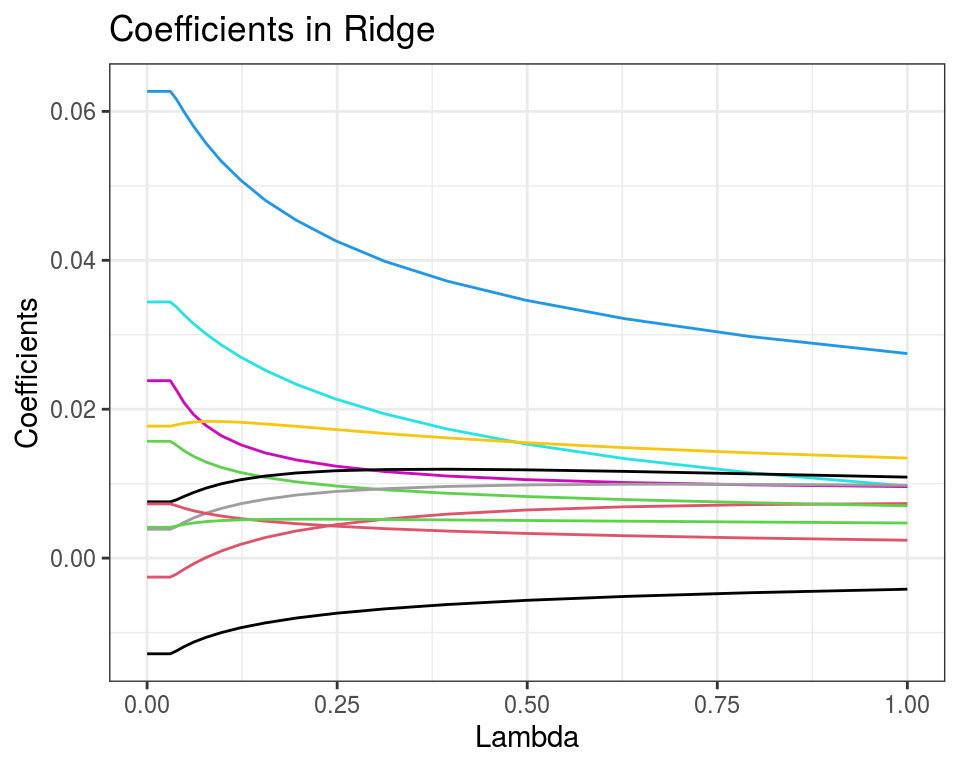

```r
Ridge<-train2[seq_len(nrow(lambda_grid)),]%>%select(-sale_price)
Lasso<-train2[seq_len(nrow(lambda_grid)),]%>%select(-sale_price)

Intercept<-c(0)
Ridge<-cbind(Intercept,Ridge)
Lasso<-cbind(Intercept,Lasso)

Ridge<-cbind(lambda_grid,Ridge)
Lasso<-cbind(lambda_grid,Lasso)

Ridge_t<-as.data.frame(t(Ridge))
Lasso_t<-as.data.frame(t(Lasso))

for (i in 1:100) {
  Ridge_t[-1,i]<-coefficient_lambda(lambda_grid$penalty[i],0)
  Lasso_t[-1,i]<-coefficient_lambda(lambda_grid$penalty[i],1)
}

Ridge_coeffi<-as.data.frame(t(Ridge_t))
Lasso_coeffi<-as.data.frame(t(Lasso_t))


ggplot(data=Ridge_coeffi) +
  geom_line(aes(x=penalty,y=ms_sub_class), color="1") +
  geom_line(aes(x=penalty,y=lot_frontage), color="2") +
  geom_line(aes(x=penalty,y=lot_area), color="3") +
  geom_line(aes(x=penalty,y=overall_qual,), color="4") +
  geom_line(aes(x=penalty,y=overall_cond), color="5") +
  geom_line(aes(x=penalty,y=year_built), color="6") +
  geom_line(aes(x=penalty,y=year_remod_add), color="7")+
  geom_line(aes(x=penalty,y=mas_vnr_area), color="8")+
  geom_line(aes(x=penalty,y=bsmt_fin_sf1), color="9")+
  geom_line(aes(x=penalty,y=bsmt_fin_sf2), color="10")+
  geom_line(aes(x=penalty,y=bsmt_unf_sf), color="11")+
  labs(title="Coefficients in Ridge", x ="Lambda", y = "Coefficients")
```

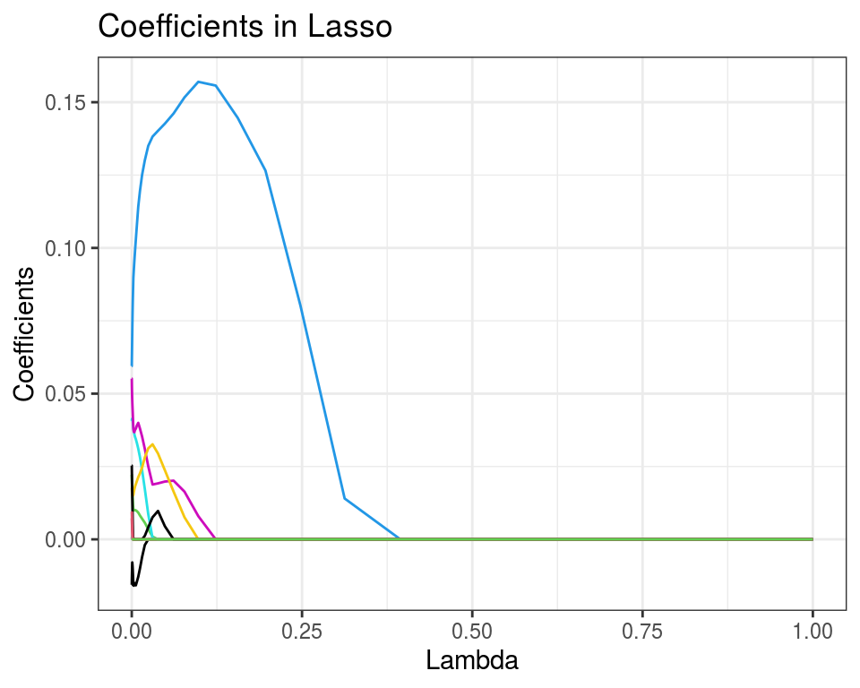

```r
ggplot(data=Lasso_coeffi) +
  geom_line(aes(x=penalty,y=ms_sub_class), color="1") +
  geom_line(aes(x=penalty,y=lot_frontage), color="2") +
  geom_line(aes(x=penalty,y=lot_area), color="3") +
  geom_line(aes(x=penalty,y=overall_qual,), color="4") +
  geom_line(aes(x=penalty,y=overall_cond), color="5") +
  geom_line(aes(x=penalty,y=year_built), color="6") +
  geom_line(aes(x=penalty,y=year_remod_add), color="7")+
  geom_line(aes(x=penalty,y=mas_vnr_area), color="8")+
  geom_line(aes(x=penalty,y=bsmt_fin_sf1), color="9")+
  geom_line(aes(x=penalty,y=bsmt_fin_sf2), color="10")+
  geom_line(aes(x=penalty,y=bsmt_unf_sf), color="11")+
  labs(title="Coefficients in Lasso", x ="Lambda", y = "Coefficients")
```

위에서 만든 데이터 테이블을 토대로 그래프를 그려보았다. 아직 변수를 다 담는 방법을 몰라 11개 변수를 선정하여 넣었다.

Lasso 의 경우 Penalty가 증가할수록 선정한 모든 변수들이 나중에는 모두 0으로 수렴하는 것을 알 수 있다.  
Lasso 와 달리 Ridge 에서는 완전 0으로 수렴하는 경우가 없는 것을 확인할 수 있다.

```r
write.csv(Ridge_coeffi, row.names = FALSE,
          "Ridge.csv")

write.csv(Lasso_coeffi, row.names = FALSE,
          "Lasso.csv")
```